# Task 3 - Urchins

Lucas Boyd

10/24/2021

# Overview

This document wrangles and visualizes data from the Santa Barbara Long Term Ecological Research Program, in which they observed size distribution of urchin populations off the coast of Santa Barbara over a 12 year period. First, it compares size distributions between species of urchins, then looks at urchin populations across all sites over time.

```r
knitr::opts_chunk$set(echo = TRUE, message = FALSE, warning = FALSE)
options(digits = 3) # reducing decimal places to 3 sig figs

# attach packages
library(tidyverse)
library(here)
library(janitor)
library(kableExtra)
library(lubridate)
```

### Reading in the urchins data

**Data Citation:** Reed, D. 2020. SBC LTER: Reef: Long-term experiment: Kelp removal: Urchin size frequency distribution ver 20. Environmental Data Initiative. https://doi.org/10.6073/pasta/5a1e9ef03aa47bd2225c0bb98a02a63b.

**Summary of variables:**

- date: date urchin recorded
- site: site along the SB coast (the five sites can be explored here)
- treatment: indicates experimental kelp treatments
  - CONTROL = giant kelp left intact
  - ANNUAL = giant kelp is “removed…once each winter and allowed to re-colonize over the course of the year”
- size: urchin diameter (cm), measured to the nearest 0.5 cm
- scientific_name = scientific name
- common_name: species common name (either red or purple urchin)

```r
urchins <- read_csv(here("data", "urchins.csv")) %>% # read in the urchins data
  clean_names() # clean up the column names
```

## Section 1

### Visualizing - Histogram

Create a histogram that shows the distribution of sizes for red and purple urchins.

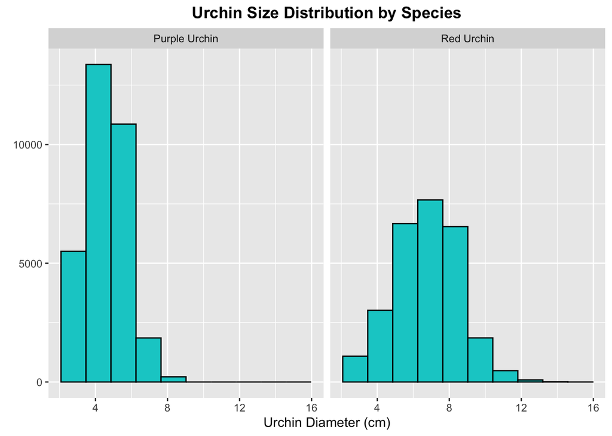

Fig. 1 compares the distribution of sizes (diameter, in cm) for red and purple urchins. Note: Urchin Diameter was recorded to the nearest 0.5cm.

```r
ggplot(data = urchins, aes(x = size)) + # creating a ggplot with urchin size on the x axis
  geom_histogram(bins = 10, color = "black", fill = "cyan3") + # creating a histogram
  facet_wrap(~ common_name) +
  labs(x = "Urchin Diameter (cm)", # changing the labels and removing the y axis label
       y = element_blank(),
       title = "Urchin Size Distribution by Species") +
  theme_grey() + # changing the theme
theme(plot.title = element_text(face = "bold", hjust = 0.5))
```

### Descriptive Statistics Table

Finding summary statistics for Urchin Data

```r
urchins_summary <- urchins %>% # creating a subset of data for urchins summary statistics
  group_by(common_name) %>% # grouping data by species
  summarize(mean_urchin_size = mean(size),# summarizing data for mean, median, SD and sample size
            median_urchin_size = median(size),
            sd_urchin_size = sd(size),
            sample_size = n())
```

Creating a table that include descriptive summary statistics for the urchins data.

```r
urchins_summary %>% # starting with the urchins summary data
  kable(col.names = c("Common Name", # changing the column names
                      "Mean Urchin Diameter (cm)",
                      "Median Urchin Size (cm)",
                      "Standard Deviation (cm)",
                      "Sample Size (n)"),
        caption = "Fig. 2 provides summary statistics for the size distribution between red and purple urchins." ) %>% # add a caption
  kable_styling(full_width = FALSE, font = 13) # tidying up the appearance of the table
```

Fig. 2 provides summary statistics for the size distribution between red and purple urchins.

| Common Name | Mean Urchin Diameter (cm) | Median Urchin Size (cm) | Standard Deviation (cm) | Sample Size (n) |
| --- | --- | --- | --- | --- |
| Purple Urchin | 4.47 | 4.5 | 1.18 | 31805 |
| Red Urchin | 6.78 | 7.0 | 1.89 | 27408 |

### Conclusions

As shown in figure 1, the purple urchins are highly concentrated on the lower end of the size distributions, where Red urchins are more normally distributed. This size difference is also highlighted in the summary statistics, where Red urchins are 52% larger on average. Higher standard deviation for red urchins also indicates a higher variance in the sample taken.

## Section 2

### Data wrangling - Purple urchins

Creating a data subset for purple urchins.

```r
purple_urchins <- urchins %>%  # starting with urchins
  filter(common_name == "Purple Urchin") %>% # only retain purple urchin observations
  mutate(date_new = mdy(date)) %>% # convert the years to proper format
  mutate(year = year(date_new)) %>% # add a column for year
  mutate(site_full = case_when( # add a column with the full site names
    site == "NAPL" ~ "Naples Reef",
    site == "AQUE" ~ "Arroyo Quemado Reef",
    site == "CARP" ~ "Carpinteria Reef",
    site == "MOHK" ~ "Mohawk Reef",
    site == "IVEE" ~ "Isla Vista Reef"
  ))
```

### Data Wrangling - by site and year

Writing code to make a table containing total number of purple urchins observed by site and year.

```r
purple_urchins_summary <- purple_urchins %>% # storing a new data frame from purple_urchins
  count(site_full, year) # counting total observations by site and year
```

### Data visualization - by site and year

Visualizing the purple urchin counts by site and year.

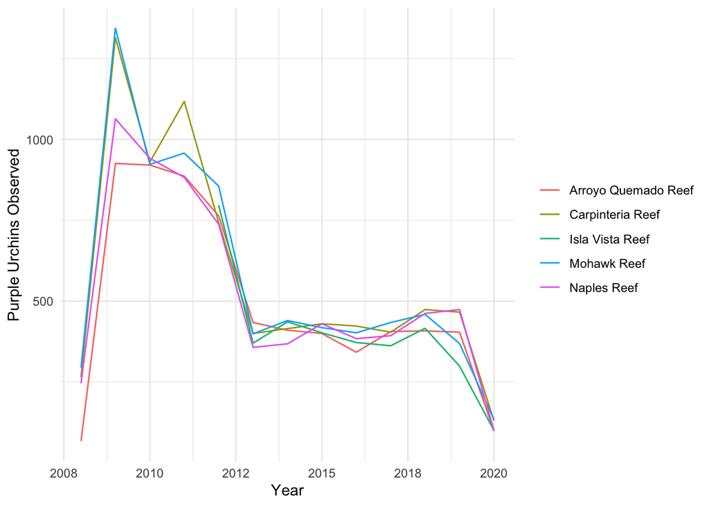

Fig 3. shows total observations of purple urchins each year at each site, seemingly indicating a downward trend in purple urchin population across all sites.

```r
ggplot(data = purple_urchins_summary, # ggplot of summary data
       aes(x = year, # year on the x axis
           y = n, # total count on the y
           color = site_full)) + # color by site name
  geom_line() + #create a line graph
  theme_minimal() + # chang the theme
  theme(legend.title = element_blank()) + # removing legend title
  labs(x = "Year", y = "Purple Urchins Observed") # changing label names
```

#### Analysis

This graph seems to show a declining urchin population across all sites in which observations were taken. In order to determine whether this data is reflective of actual changes in urchin population, we would need to know the frequency of data collection. How often were the divers going out to collect observations? If they were collecting less data, this could also explain the fewer observations over time.